# xwMOOC 모형

예측모형 GDPR 도전

2018-10-05

# 1 기계학습 알고리즘

기계학습 알고리즘(예를 들어, 로지스틱 회귀 알고리즘)부터 이야기를 풀어보자.

## 1.1 `glm` 알고리즘 검증 [^1] [^2]

위키백과사전에 공개된 공부시간에 따른 합격률 데이터를 살펴보자. 공부시간은 연속형 변수가 되고 합격여부는 0, 1로 표현된 범주형 변수다. 이를 `glm` 알고리즘을 통해 모형에 적합시켜 공부시간이 합격에 주는 영향도를 살펴보고 시각적으로 확인해 보자.

$$\text{합격 확률} = \frac{1} {1 + \exp \left( - \left( 1.5046 \cdot \text{공부시간} - 4.0777 \right) \right) }$$

```r
> # 0. 환경설정 ------
> library(tidyverse)
>
> # 1. 데이터 ------
> exam_df <- tribble(~Hours, ~Pass,
+         0.5   ,    0,
+         0.75, 0,
+         1    ,    0,
+         1.25, 0,
+         1.5 , 0,
+         1.75, 0,
+         1.75, 1,
+         2   , 0,
+         2.25, 1,
+         2.5  ,    0,
+         2.75, 1,
+         3   , 0,
+         3.25, 1,
+         3.5   ,    0,
+         4    , 1,
+         4.25, 1,
+         4.5   ,    1,
+         4.75, 1,
+         5    , 1,
+         5.5   ,    1)
>
> # 2. 예측모형 ------
> exam_glm <- glm(Pass ~ Hours, data=exam_df, family="binomial")
>
> exam_glm %>% broom::tidy()
```

```
         term  estimate std.error statistic    p.value
1 (Intercept) -4.077713 1.7609843 -2.315588 0.02058080
2       Hours  1.504645 0.6287165  2.393202 0.01670205
```

공부시간 증가에 따른 로그오즈, 오즈, 합격확률 증가는 다음과 같이 표현이 가능하다.

| 공부시간 | 로그오즈 | 오즈 | 합격확률 |
| --- | --- | --- | --- |
| 1 | - 2.57 | 0.076 $\approx$ 1:13.1 | 0.07 |
| 2 | -1.07 | 0.34 $\approx$ 1:2.91 | 0.26 |
| 3 | 0.44 | 1.55 | 0.61 |
| 4 | 1.94 | 6.96 | 0.87 |
| 5 | 3.45 | 31.4 | 0.97 |

이를 `broom` 팩키지를 통해서 시각화를 하여 공부시간 증가에 따른 합격확률 변화를 확인하는 것이 가능하다.

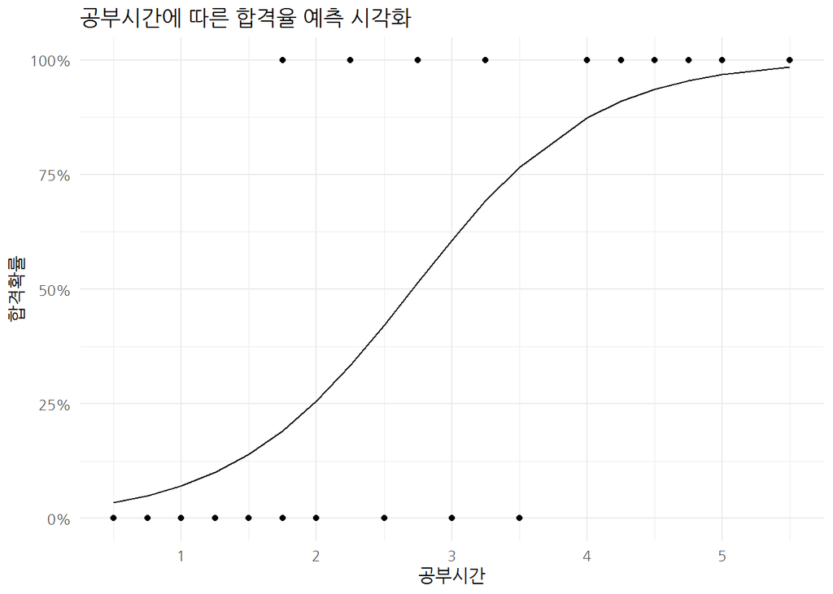

```r
> # 3. 예측 시각화 ------
> library(broom)
> library(extrafont)
> loadfonts()
>
> exam_viz_df <- augment(exam_glm, exam_df,  type.predict = "prob")
>
> exam_viz_df %>%
+     ggplot(aes(x=Hours, y=Pass)) +
+       geom_point() +
+       geom_line(aes(x=Hours, y=.fitted)) +
+       labs(x="공부시간", y="합격확률", title="공부시간에 따른 합격율 예측 시각화") +
+       scale_y_continuous(labels=scales::percent) +
+       theme_minimal(base_family="NanumGothic")
```

```r
> # library(effects)
> # exam_glm_eff <- allEffects(exam_glm)
> # plot(exam_glm_eff)
```

## 1.2 기계학습 예측모형 [^3]

### 1.2.1 예측모형 구축

[xwMOOC 모형 - 예측모형 가치(Business Value)](https://statkclee.github.io/model/model-business-value.html)에서 사용된 데이터를 재사용하여 예측모형을 구축한다. 데이터가 크면 학습 시간이 오래걸리는 문제가 있어 전체 데이터중에 10%만 무작위로 표본추출하여 예측모형개발에 사용한다.

```r
> # 1.2. 불러오기 -----
> bank_dat <- read_delim("data/bank-additional/bank-additional-full.csv", delim=";",
+                       col_types = cols(
+                               .default = col_character(),
+                               age = col_integer(),
+                               duration = col_integer(),
+                               campaign = col_integer(),
+                               pdays = col_integer(),
+                               previous = col_integer(),
+                               emp.var.rate = col_double(),
+                               cons.price.idx = col_double(),
+                               cons.conf.idx = col_double(),
+                               euribor3m = col_double(),
+                               nr.employed = col_double()))
>
>
> bank_df <- bank_dat %>%
+     select_('y','duration','campaign','pdays','previous','euribor3m') %>%
+     mutate(y = factor(y, levels=c('no', 'yes'))) %>%
+     sample_frac(0.1)
```

훈련/시험 데이터로 나누고, 일반화선형모형(GLM), 의사결정나무(RPART), GBM모형을 각각 적합시킨다. 예측모형 개발에 시간이 많이 소요되기 때문에 `doSNOW` 팩키지를 통해 병렬처리 방식으로 예측모형개발을 수행한다.

```r
> # 2. 예측모형 -----
> ## 2.1. 훈련/시험 데이터 분할 ------
> library(caret)
> library(lares) # devtools::install_github("laresbernardo/lares")
>
> bank_index <- createDataPartition(bank_df$y, times =1, p=0.3, list=FALSE)
>
> train_df <- bank_df[bank_index, ]
> test_df  <- bank_df[-bank_index, ]
>
> ## 2.2. 모형 개발/검증 데이터셋 준비 ------
>
> cv_folds <- createMultiFolds(train_df$y, k = 5, times = 1)
>
> cv_cntrl <- trainControl(method = "repeatedcv", number = 5,
+                          repeats = 1, index = cv_folds)
>
>
> ## 2.3. 예측모형 아키텍처 ------
> library(doSNOW)
> # 실행시간
> start.time <- Sys.time()
>
> cl <- makeCluster(4, type = "SOCK")
> registerDoSNOW(cl)
>
> bank_rpart <- train(y ~ ., data = train_df,
+                     method = "rpart",
+                     metric = "Accuracy",
+                     trControl = cv_cntrl,
+                     tuneLength = 7)
>
> bank_glm   <- train(y ~ ., data = train_df,
+                     method = "glm",
+                     family = "binomial",
+                     metric = "Accuracy",
+                     trControl = cv_cntrl,
+                     tuneLength = 7)
>
> bank_gbm    <- train(y ~ ., data = train_df,
+                      method = "xgbTree",
+                      # metric = "Sens",
+                      metric = "Accuracy",
+                      trControl = cv_cntrl,
+                      tuneLength = 7,
+                      importance = TRUE)
>
> stopCluster(cl)
>
> total.time <- Sys.time() - start.time
> total.time
```

```
Time difference of 2.528103 mins
```

### 1.2.2 예측모형 비교

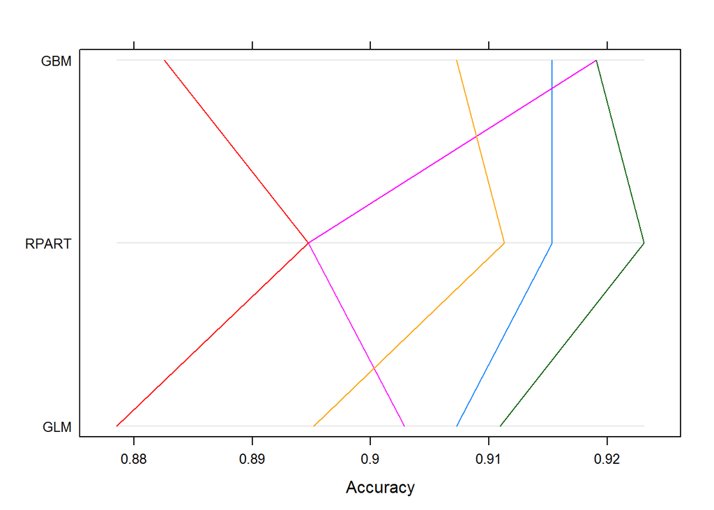

```r
> # 3. 모형 아키텍처 평가 ------
> all_samples <- resamples(list("GLM"    = bank_glm,
+                                "RPART" = bank_rpart,
+                                "GBM"   = bank_gbm))
>
> parallelplot(all_samples)
```

### 1.2.3 이득(Gains)과 향상도(Lift) 측도

각 십분위수(Decile) 별로 향상도(Lift)와 이득(Gains)을 계산하여 이를 시각화하여 보완한다.

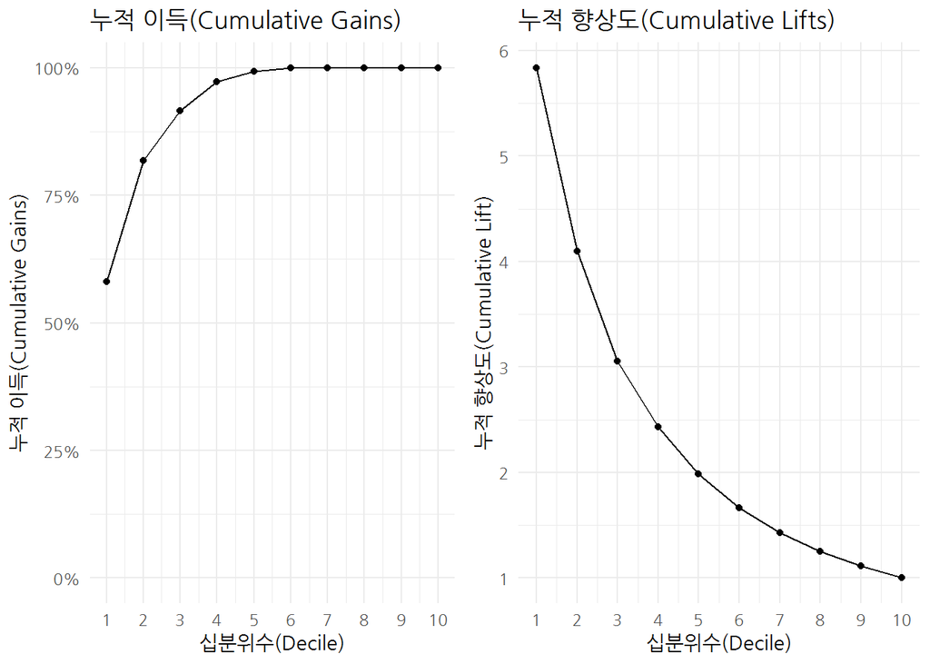

```r
> # 4. 사업 평가 -----
> score_df <- tibble(
+     label = train_df$y,
+     gbm_score = predict(bank_gbm, newdata=train_df, type="prob")[,2]
+ )
>
> # library(gains)
> # gains(as.integer(score_df$label)-1, score_df$gbm_score)
>
> score_decile_df <- score_df %>%
+     mutate(decile = ntile(gbm_score, 10)) %>%
+     count(decile, label) %>%
+     spread(label,n, fill=0)  %>%
+     mutate(decile = 11-decile) %>%
+     arrange(decile) %>%
+     mutate(total = no + yes,
+            cum_yes = cumsum(yes),
+            cum_tot = cumsum(total)) %>%
+     mutate(gain = yes /sum(yes),
+            cum_gains = cum_yes / sum(yes)) %>%
+     mutate(avg_resp = sum(yes)/sum(total)) %>%
+     mutate(lift = (yes/total) / avg_resp,
+            cum_lift = (cum_yes/cum_tot) / avg_resp)
>
> cumulative_gain_g <- score_decile_df %>%
+     ggplot(aes(x=decile, y=cum_gains)) +
+       geom_point() +
+       geom_line() +
+       scale_y_continuous(limits=c(0,1), labels = scales::percent) +
+       scale_x_continuous(breaks = seq(1,10)) +
+       labs(x="십분위수(Decile)", y="누적 이득(Cumulative Gains)", title="누적 이득(Cumulative Gains)") +
+       theme_minimal(base_family="NanumGothic")
>
> cumulative_lift_g <- score_decile_df %>%
+     ggplot(aes(x=decile, y=cum_lift)) +
+       geom_point() +
+       geom_line() +
+       scale_x_continuous(breaks = seq(1,10)) +
+       labs(x="십분위수(Decile)", y="누적 향상도(Cumulative Lift)", title="누적 향상도(Cumulative Lifts)") +
+       theme_minimal(base_family="NanumGothic")
>
> cowplot::plot_grid(cumulative_gain_g, cumulative_lift_g)
```

### 1.2.4 예측모형 사업 평가

`lares` 팩키지 내장된 함수를 사용해서… 사업평가도 수행할 수 있다. `mplot_density()`, `mplot_roc()`, `mplot_cuts()`, `mplot_splits()` 함수 기능이 유용한 기능을 제공하고, `mplot_full()` 함수로 분류문제 예측모형에 대한 사업평가는 한장표에 전반적인 정보를 제공하고 있다.

[figure not shown]

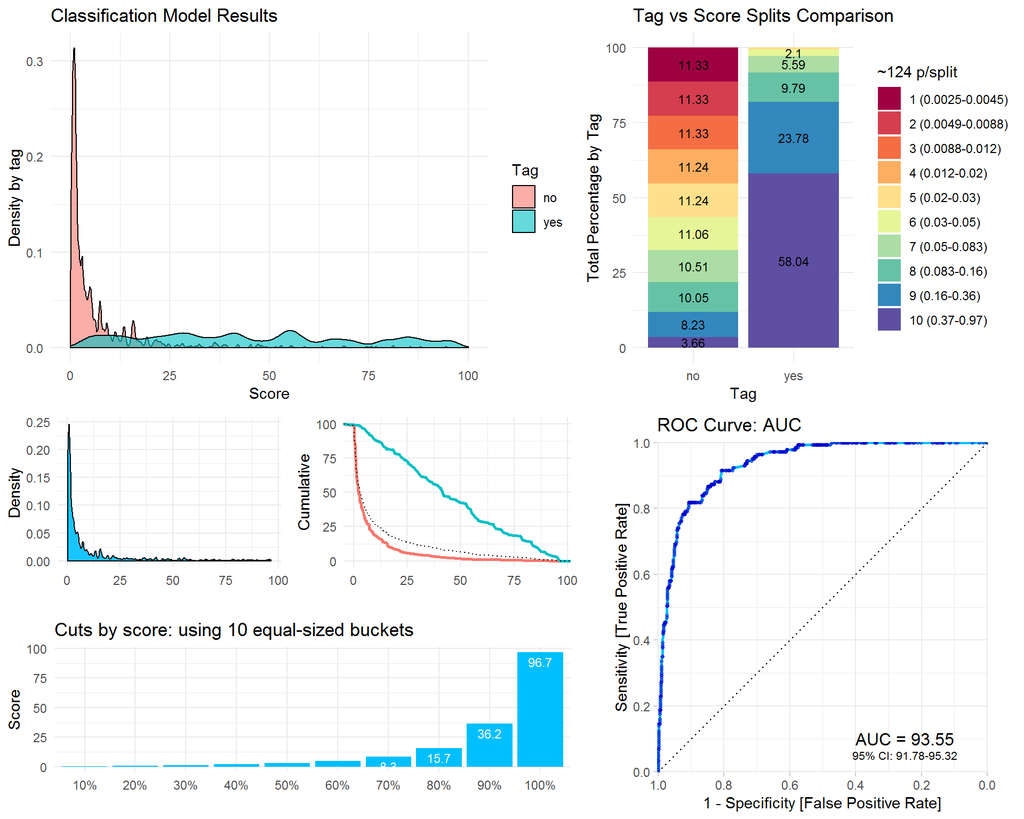

```r
> # 5. 사업 평가 -----
>
> # mplot_density(score_df$label, score_df$gbm_score)
> # mplot_roc(score_df$label, score_df$gbm_score )
> # mplot_cuts(score_df$gbm_score, splits=10 )
> # mplot_splits(score_df$label, score_df$gbm_score,  splits = 10)
>
> mplot_full(score_df$label, score_df$gbm_score, splits=10)
```

[^1]: [Wikipedia, “Logistic regression”](https://en.wikipedia.org/wiki/Logistic_regression)
[^2]: [OPEN SOURCE AUTOMATION - Automating everyday tasks with open source code (2018), “HOW TO BUILD A LOGISTIC REGRESSION MODEL FROM SCRATCH IN R”](http://theautomatic.net/2018/10/02/how-to-build-a-logistic-regression-model-from-scratch-in-r/)
[^3]: [Bernardo Lares(2018), “Machine Learning Results in R: one plot to rule them all! (Part 1 – Classification Models)”](https://datascienceplus.com/machine-learning-results-one-plot-to-rule-them-all/)